# (SSA) VE of Nirsevimab

### Figure 1. Look at distribution of testing by time

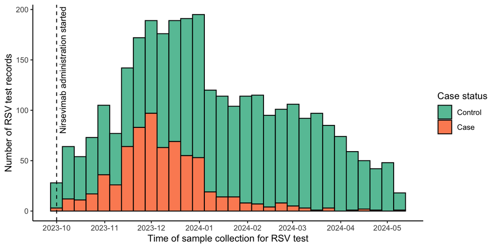

### Look at the risk factors

#### Table 1 Each risk factor

| risk_factor | n_records | perc |
| --- | --- | --- |
| gestage_lessthan37wks | 418 | 13.5 |
| small_for_gestage | 339 | 11 |
| pulmonary_disease | 156 | 5 |
| cardiac | 152 | 4.9 |
| anemia | 94 | 3 |
| down_syndrome | 14 | 0.5 |
| immunodeficiency | 6 | 0.2 |
| blood | 0 | 0 |

#### Table 2 At least one risk factor

| risk_factor_atleastone | n | perc |
| --- | --- | --- |
| no | 2340 | 75.7 |
| yes | 750 | 24.3 |

### Table 3. Characteristic of study population (testing level)

#### RSV+ vs. RSV-

| Characteristic | Overall, N = 3,0901 | RSV-, N = 2,4101 | RSV+, N = 6801 | p-value2 |
| --- | --- | --- | --- | --- |
| Sex |  |  |  | 0.498 |
| Female | 1,317 (42.6%) | 1,038 (43.1%) | 279 (41.0%) |  |
| Male | 1,772 (57.3%) | 1,371 (56.9%) | 401 (59.0%) |  |
| (Missing) | 1 (0.0%) | 1 (0.0%) | 0 (0.0%) |  |
| Age at testing (months) |  |  |  | 0.007 |
| Mean (SD) | 6.9 (4.0) | 7.0 (4.1) | 6.5 (3.7) |  |
| Median (IQR) | 6.7 (3.6, 9.7) | 6.9 (3.7, 9.9) | 6.1 (3.4, 9.2) |  |
| N missing (% missing) | 0.0 (0.0%) | 0.0 (0.0%) | 0.0 (0.0%) |  |
| Age at testing |  |  |  | 0.016 |
| under 3m | 620 (20.1%) | 477 (19.8%) | 143 (21.0%) |  |
| 3-6m | 739 (23.9%) | 553 (22.9%) | 186 (27.4%) |  |
| 6-9m | 787 (25.5%) | 618 (25.6%) | 169 (24.9%) |  |
| 9-12m | 569 (18.4%) | 448 (18.6%) | 121 (17.8%) |  |
| above 1 yo | 375 (12.1%) | 314 (13.0%) | 61 (9.0%) |  |
| Time tested |  |  |  | <0.001 |
| Oct-Nov | 814 (26.3%) | 507 (21.0%) | 307 (45.1%) |  |
| Dec-Jan | 1,246 (40.3%) | 913 (37.9%) | 333 (49.0%) |  |
| Feb-Mar | 781 (25.3%) | 746 (31.0%) | 35 (5.1%) |  |
| April and after | 249 (8.1%) | 244 (10.1%) | 5 (0.7%) |  |
| Race and ethnicity |  |  |  | 0.086 |
| Hispanic | 1,328 (43.0%) | 1,048 (43.5%) | 280 (41.2%) |  |
| White non-Hispanic | 820 (26.5%) | 619 (25.7%) | 201 (29.6%) |  |
| Black non-Hispanic | 533 (17.2%) | 421 (17.5%) | 112 (16.5%) |  |
| Other non-Hispanic3 | 161 (5.2%) | 135 (5.6%) | 26 (3.8%) |  |
| unknown | 248 (8.0%) | 187 (7.8%) | 61 (9.0%) |  |
| Birth weight |  |  |  | 0.067 |
| Mean (SD) | 3,131.7 (687.3) | 3,117.8 (702.5) | 3,182.1 (626.4) |  |
| Median (IQR) | 3,214.3 (2,824.9, 3,563.8) | 3,194.5 (2,805.1, 3,553.6) | 3,265.0 (2,875.0, 3,576.2) |  |
| N missing (% missing) | 783.0 (25.3%) | 599.0 (24.9%) | 184.0 (27.1%) |  |
| Missing | 783.0 | 599.0 | 184.0 |  |
| Gestational age |  |  |  | 0.045 |
| 37 weeks or more | 1,915 (62.0%) | 1,496 (62.1%) | 419 (61.6%) |  |
| Less than 37 weeks | 418 (13.5%) | 342 (14.2%) | 76 (11.2%) |  |
| (Missing) | 757 (24.5%) | 572 (23.7%) | 185 (27.2%) |  |
| Pulmonary diseases | 156 (5.0%) | 130 (5.4%) | 26 (3.8%) | 0.099 |
| Cardiac diseases | 152 (4.9%) | 122 (5.1%) | 30 (4.4%) | 0.489 |
| Anemia | 94 (3.0%) | 79 (3.3%) | 15 (2.2%) | 0.151 |
| Having at least one risk factor4 | 750 (24.3%) | 600 (24.9%) | 150 (22.1%) | 0.127 |
| Insurance type |  |  |  | 0.092 |
| private | 983 (31.8%) | 752 (31.2%) | 231 (34.0%) |  |
| public | 2,088 (67.6%) | 1,646 (68.3%) | 442 (65.0%) |  |
| uninsured | 19 (0.6%) | 12 (0.5%) | 7 (1.0%) |  |
| mAb status |  |  |  | <0.001 |
| No | 2,773 (89.7%) | 2,113 (87.7%) | 660 (97.1%) |  |
| Yes, 100mg dose | 93 (3.0%) | 87 (3.6%) | 6 (0.9%) |  |
| Yes, 50mg dose | 224 (7.2%) | 210 (8.7%) | 14 (2.1%) |  |

1n (%)  
2Fisher's exact test; Wilcoxon rank sum test; Pearson's Chi-squared test  
3Inclusing Asian, Pacific Islander, Middle Eastern or Northern American, American Indian or Native American by self-reporting.  
4Have at least one of the following conditions recorded in the infant's medical history or diagnosis records: 1) Anemia; 2) Immunodeficiency (e.g. transplantation history, leukemia, etc.); 3) Cardiac diseases (including congenital heart diseases diagnosed at birth or any reporting of heart conditions); 4) Pulmonary diseases; 5) Down syndrome; 6) Small for gestational age (birth weight < 2,500 grams); 7) Prematurity (gestational age less than 37 weeks).

### Clinical outcomes

#### Table 4.

Here we filtered out only the cases (RSV+) and compare between vaccinated and unvaccinated.

| Characteristic | Overall, N = 6801 | Unvaccinated, N = 6601 | Vaccinated, N = 201 |
| --- | --- | --- | --- |
| Hospital admission | 166 (24.4%) | 161 (24.4%) | 5 (25.0%) |
| Duration of hospitalization (days) |  |  |  |
| Median (IQR) | 1.0 (1.0, 2.0) | 1.0 (1.0, 2.0) | 3.0 (2.0, 3.0) |
| N missing (% missing) | 514.0 (75.6%) | 499.0 (75.6%) | 15.0 (75.0%) |
| Missing | 514.0 | 499.0 | 15.0 |
| ICU admission | 23 (3.4%) | 22 (3.3%) | 1 (5.0%) |
| Duration of ICU admission (days) |  |  |  |
| Median (IQR) | 3.1 (1.8, 7.3) | 3.5 (1.8, 7.4) | 2.4 (2.4, 2.4) |
| N missing (% missing) | 657.0 (96.6%) | 638.0 (96.7%) | 19.0 (95.0%) |
| Missing | 657.0 | 638.0 | 19.0 |
| Required highflow oxygen support | 145 (21.3%) | 141 (21.4%) | 4 (20.0%) |
| Distress in URT | 229 (33.7%) | 222 (33.6%) | 7 (35.0%) |
| Distress in LRT | 361 (53.1%) | 350 (53.0%) | 11 (55.0%) |
| Fever (> 38°C/100.4°F) | 239 (35.1%) | 235 (35.6%) | 4 (20.0%) |
| Cough | 98 (14.4%) | 94 (14.2%) | 4 (20.0%) |
| Wheezing | 9 (1.3%) | 9 (1.4%) | 0 (0.0%) |
| Breathing difficulties | 3 (0.4%) | 3 (0.5%) | 0 (0.0%) |
| Bronchiolitis | 349 (51.3%) | 338 (51.2%) | 11 (55.0%) |
| Sepsis | 2 (0.3%) | 2 (0.3%) | 0 (0.0%) |

1n (%)

### Used the same confounders as in the main analysis

```r
confounders_infection <- c(
  "age_at_test_in_months_cat_2", # 3-month interval
  "month_when_tested_cat"
)

confounders_ed <- c(
  "age_at_test_in_months_cat_2", # 3-month interval
  "month_when_tested_cat"
)

confounders_inpatient <- c(
  "age_at_test_in_months_cat_2", # 3-month interval
  "month_when_tested_cat",
  "risk_factor_atleastone"
)

confounders_severe <- c(
  "age_at_test_in_months_cat_2", # 3-month interval
  "month_when_tested_cat",
  "risk_factor_atleastone"
)

confounders_LRTI <- c(
  "age_at_test_in_months_cat_2", # 3-month interval
  "month_when_tested_cat",
  "risk_factor_atleastone"
)

confounders_LRTIhosp <- c(
  "age_at_test_in_months_cat_2", # 3-month interval
  "month_when_tested_cat",
  "risk_factor_atleastone"
)


all_confounders <- c(
  "age_at_test_in_months_cat_2", # 3-month interval
  "month_when_tested_cat",
  "race_ethnicity",
  #"risk_factor_gestagelessthan37wks",
  "risk_factor_atleastone",
  "insurance_type"
)
```

### Table 5. Effectiveness of Nirsevimab

#### Table 5.

| against | n_cases_mab | n_cases_nomab | n_controls_mab | n_controls_nomab | ve_unadj | ve_adj |
| --- | --- | --- | --- | --- | --- | --- |
| Medically attended RSV infection | 20 (20) | 660 (660) | 297 (297) | 2113 (2113) | 78.4 (66.7-86.8) | 66.7 (47.2-80) |
| RSV-associated hospitalization | 5 (5) | 161 (161) | 60 (60) | 317 (317) | 83.6 (62.1-94.4) | 74.2 (35.8-91.5) |
| RSV-associated outpatient visit | 15 (15) | 499 (499) | 230 (230) | 1761 (1761) | 77 (62.2-87) | 63.4 (37.8-79.9) |
| RSV-associated LRTI | 11 (11) | 350 (350) | 56 (56) | 326 (326) | 81.7 (65.8-91) | 70.2 (38.7-86.4) |
| RSV-associated LRTI hospitalization | 5 (5) | 145 (145) | 21 (21) | 119 (119) | 80.5 (50.4-93.6) | 62.8 (-18.5-89.7) |
| RSV-associated severe outcomes | 4 (4) | 141 (141) | 70 (70) | 220 (220) | 91.1 (77.9-97.3) | 79.4 (44.1-94.2) |

#### Figure 2. (2 rows for each outcome)

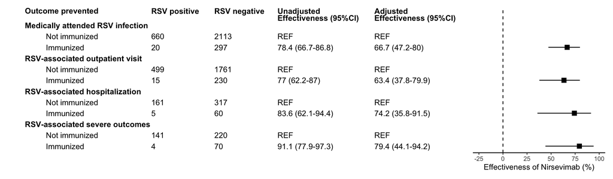

### Earlier records

Look at when restricting to records up to March, if the results are the same as what was reported in the ACIP meeting by CDC.

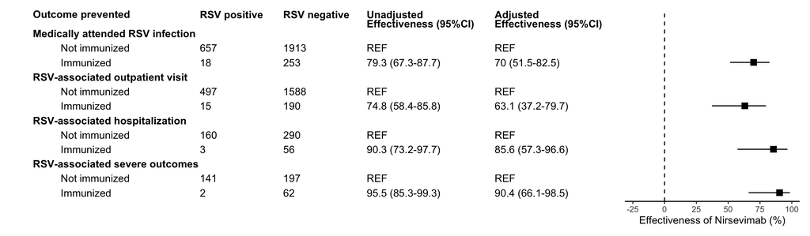

### Look at whether dosage has an influence on VE.

#### Table 7 Compare infants who took 100mg and 50mg dosage

| Characteristic | Overall, N = 3171 | 100mg, N = 931 | 50mg, N = 2241 | p-value2 |
| --- | --- | --- | --- | --- |
| Sex |  |  |  | 0.136 |
| Female | 133 (42.0%) | 33 (35.5%) | 100 (44.6%) |  |
| Male | 184 (58.0%) | 60 (64.5%) | 124 (55.4%) |  |
| (Missing) | 0 (0.0%) | 0 (0.0%) | 0 (0.0%) |  |
| Age at testing (months) |  |  |  | <0.001 |
| Mean (SD) | 4.3 (3.0) | 7.5 (2.7) | 3.0 (2.0) |  |
| Median (IQR) | 3.5 (1.9, 6.0) | 7.3 (5.7, 8.9) | 2.5 (1.6, 3.8) |  |
| N missing (% missing) | 0.0 (0.0%) | 0.0 (0.0%) | 0.0 (0.0%) |  |
| Age at testing |  |  |  | <0.001 |
| under 3m | 130 (41.0%) | 1 (1.1%) | 129 (57.6%) |  |
| 3-6m | 104 (32.8%) | 27 (29.0%) | 77 (34.4%) |  |
| 6-9m | 57 (18.0%) | 42 (45.2%) | 15 (6.7%) |  |
| 9-12m | 19 (6.0%) | 17 (18.3%) | 2 (0.9%) |  |
| above 1 yo | 7 (2.2%) | 6 (6.5%) | 1 (0.4%) |  |
| Time tested |  |  |  | 0.015 |
| Oct-Nov | 20 (6.3%) | 12 (12.9%) | 8 (3.6%) |  |
| Dec-Jan | 113 (35.6%) | 34 (36.6%) | 79 (35.3%) |  |
| Feb-Mar | 138 (43.5%) | 36 (38.7%) | 102 (45.5%) |  |
| April and after | 46 (14.5%) | 11 (11.8%) | 35 (15.6%) |  |
| Race and ethnicity |  |  |  | 0.005 |
| Hispanic | 133 (42.0%) | 33 (35.5%) | 100 (44.6%) |  |
| White non-Hispanic | 66 (20.8%) | 15 (16.1%) | 51 (22.8%) |  |
| Black non-Hispanic | 82 (25.9%) | 26 (28.0%) | 56 (25.0%) |  |
| Other non-Hispanic3 | 22 (6.9%) | 14 (15.1%) | 8 (3.6%) |  |
| unknown | 14 (4.4%) | 5 (5.4%) | 9 (4.0%) |  |
| Birth weight |  |  |  | 0.963 |
| Mean (SD) | 2,921.7 (824.2) | 2,869.4 (1,016.7) | 2,944.0 (728.6) |  |
| Median (IQR) | 3,074.5 (2,575.6, 3,443.8) | 3,114.4 (2,505.7, 3,488.8) | 3,044.7 (2,585.5, 3,436.4) |  |
| N missing (% missing) | 26.0 (8.2%) | 6.0 (6.5%) | 20.0 (8.9%) |  |
| Missing | 26.0 | 6.0 | 20.0 |  |
| Gestational age |  |  |  | 0.044 |
| 37 weeks or more | 209 (65.9%) | 60 (64.5%) | 149 (66.5%) |  |
| Less than 37 weeks | 86 (27.1%) | 31 (33.3%) | 55 (24.6%) |  |
| (Missing) | 22 (6.9%) | 2 (2.2%) | 20 (8.9%) |  |
| Pulmonary diseases | 19 (6.0%) | 11 (11.8%) | 8 (3.6%) | 0.005 |
| Cardiac diseases | 29 (9.1%) | 7 (7.5%) | 22 (9.8%) | 0.519 |
| Anemia | 10 (3.2%) | 6 (6.5%) | 4 (1.8%) | 0.069 |
| Having at least one risk factor4 | 116 (36.6%) | 40 (43.0%) | 76 (33.9%) | 0.126 |
| Insurance type |  |  |  | 0.664 |
| private | 74 (23.3%) | 20 (21.5%) | 54 (24.1%) |  |
| public | 243 (76.7%) | 73 (78.5%) | 170 (75.9%) |  |
| uninsured | 0 (0.0%) | 0 (0.0%) | 0 (0.0%) |  |

1n (%)  
2Fisher's exact test; Wilcoxon rank sum test; Pearson's Chi-squared test  
3Inclusing Asian, Pacific Islander, Middle Eastern or Northern American, American Indian or Native American by self-reporting.  
4Have at least one of the following conditions recorded in the infant's medical history or diagnosis records: 1) Anemia; 2) Immunodeficiency (e.g. transplantation history, leukemia, etc.); 3) Cardiac diseases (including congenital heart diseases diagnosed at birth or any reporting of heart conditions); 4) Pulmonary diseases; 5) Down syndrome; 6) Small for gestational age (birth weight < 2,500 grams); 7) Prematurity (gestational age less than 37 weeks).

#### Table 8 VE by dosage (100mg vs. not vaccinated)

| against | n_cases_mab | n_cases_nomab | n_controls_mab | n_controls_nomab | ve_unadj | ve_adj |
| --- | --- | --- | --- | --- | --- | --- |
| Medically attended RSV infection | 6 (6) | 660 (660) | 87 (87) | 2113 (2113) | 77.9 (53.4-91.4) | 70.9 (36.5-88.9) |
| RSV-associated hospitalization | 1 (1) | 161 (161) | 18 (18) | 317 (317) | 89.1 (46.3-99.4) | 86 (21.5-99.3) |
| RSV-associated outpatient visit | 5 (5) | 499 (499) | 69 (69) | 1761 (1761) | 74.4 (42.3-91.1) | 65.7 (19.5-88.3) |
| RSV-associated LRTI | 3 (3) | 350 (350) | 19 (19) | 326 (326) | 85.3 (56.3-96.6) | 71.6 (1.8-93.9) |
| RSV-associated LRTI hospitalization | 1 (1) | 145 (145) | 8 (8) | 119 (119) | 89.7 (43-99.5) | 72.2 (-127.6-98.8) |
| RSV-associated severe outcomes | 1 (1) | 141 (141) | 18 (18) | 220 (220) | 91.3 (57.3-99.5) | 85.6 (16.4-99.2) |

#### Table 9 VE by dosage (50mg vs. not vaccinated)

| against | n_cases_mab | n_cases_nomab | n_controls_mab | n_controls_nomab | ve_unadj | ve_adj |
| --- | --- | --- | --- | --- | --- | --- |
| Medically attended RSV infection | 14 (14) | 660 (660) | 210 (210) | 2113 (2113) | 78.7 (64.4-88.2) | 64.3 (38.2-80.8) |
| RSV-associated hospitalization | 4 (4) | 161 (161) | 42 (42) | 317 (317) | 81.2 (52.6-94.4) | 69 (14.2-91.3) |
| RSV-associated outpatient visit | 10 (10) | 499 (499) | 161 (161) | 1761 (1761) | 78.1 (60.3-89.3) | 61.8 (27.1-82) |
| RSV-associated LRTI | 8 (8) | 350 (350) | 37 (37) | 326 (326) | 79.9 (58.3-91.4) | 70.3 (30.6-88.4) |
| RSV-associated LRTI hospitalization | 4 (4) | 145 (145) | 13 (13) | 119 (119) | 74.7 (26.5-93) | 61.4 (-44.1-91.1) |
| RSV-associated severe outcomes | 3 (3) | 141 (141) | 52 (52) | 220 (220) | 91 (74.9-97.8) | 77 (28.5-94.8) |

#### Table 10. Compare VE from 50mg and 100mg dosage

| against | VE.unadjusted | VE.adjusted | VE.unadjusted | VE.adjusted |
| --- | --- | --- | --- | --- |
| Medically attended RSV infection | 78.7 (64.4-88.2) | 64.3 (38.2-80.8) | 77.9 (53.4-91.4) | 70.9 (36.5-88.9) |
| RSV-associated hospitalization | 81.2 (52.6-94.4) | 69 (14.2-91.3) | 89.1 (46.3-99.4) | 86 (21.5-99.3) |
| RSV-associated outpatient visit | 78.1 (60.3-89.3) | 61.8 (27.1-82) | 74.4 (42.3-91.1) | 65.7 (19.5-88.3) |
| RSV-associated LRTI | 79.9 (58.3-91.4) | 70.3 (30.6-88.4) | 85.3 (56.3-96.6) | 71.6 (1.8-93.9) |
| RSV-associated LRTI hospitalization | 74.7 (26.5-93) | 61.4 (-44.1-91.1) | 89.7 (43-99.5) | 72.2 (-127.6-98.8) |
| RSV-associated severe outcomes | 91 (74.9-97.8) | 77 (28.5-94.8) | 91.3 (57.3-99.5) | 85.6 (16.4-99.2) |

#### Combine plot of any dose, 100mg, 50mg

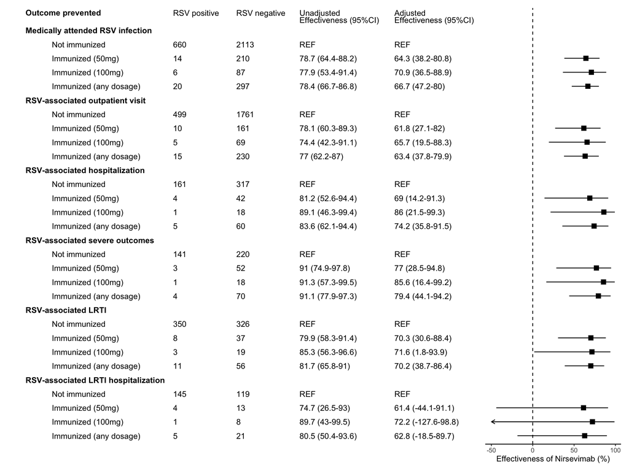

### what if we look at the VE against different age groups?

Per ACIP’s meeting slides, it would be good to look at VE among <8 months and 8-19 months. Should we classify age using age when being tested or age when nirsevimab became available (chose this).

#### convert VE under 8m to forest plot

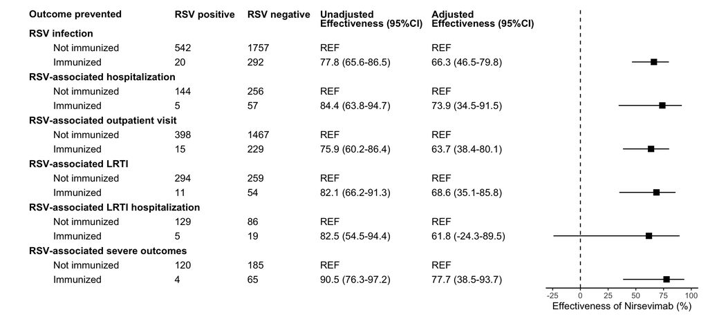

### SSA 2: information bias:

- compare rate of uptake of hep V vaccine between cases and controls
- use hep B vax as exposure to calculate VE.

#### Compare rate of uptake of hep V vaccine between cases and controls

| Characteristic | Overall, N = 3,0901 | RSV+, N = 6801 | RSV-, N = 2,4101 | p-value2 |
| --- | --- | --- | --- | --- |
| Hepatitis B vaccination | 1,728 (55.9%) | 365 (53.7%) | 1,363 (56.6%) | 0.182 |

1n (%)  
2Pearson's Chi-squared test

#### Use hep B vax as exposure to calculate VE again

- the outcomes are the same as in the main analysis

[output not shown]

### SSA 3: Selection bias:

- only those who test positive for other respiratory pathogens are selected as controls.

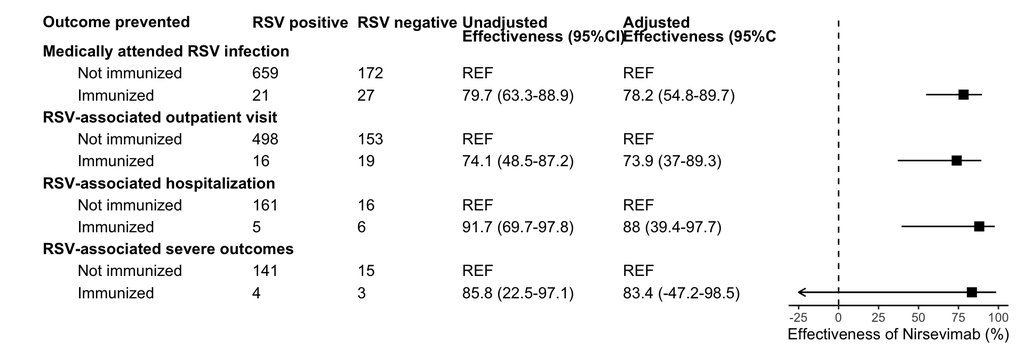

### SSA 4: Pre-existing immunity:

- exclude patients who received other RSV prophylaxis (i.e., mother received maternal vaccine).
- AND exclude patients who might have been exposed previously (born before July 1st 2023?)

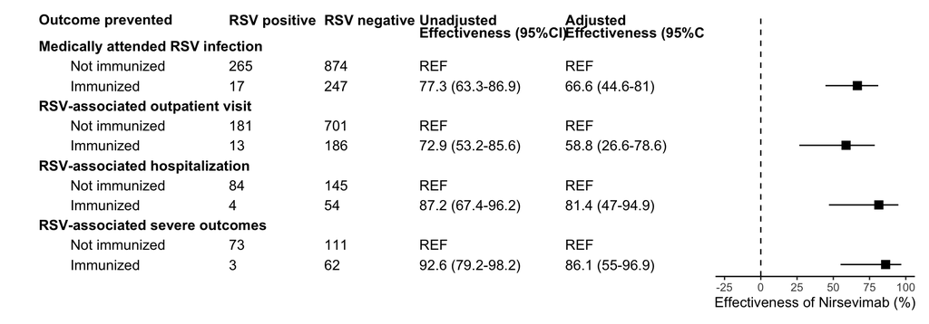

### SSA 5: restricting to earlier records

### SSA 6: restricting to young records (< 8 month-old on October 1st 2023)

### SSA 7: use RSV-associated LRTI and LRTI hospitalization as endpoint

### Combine all SSA results together

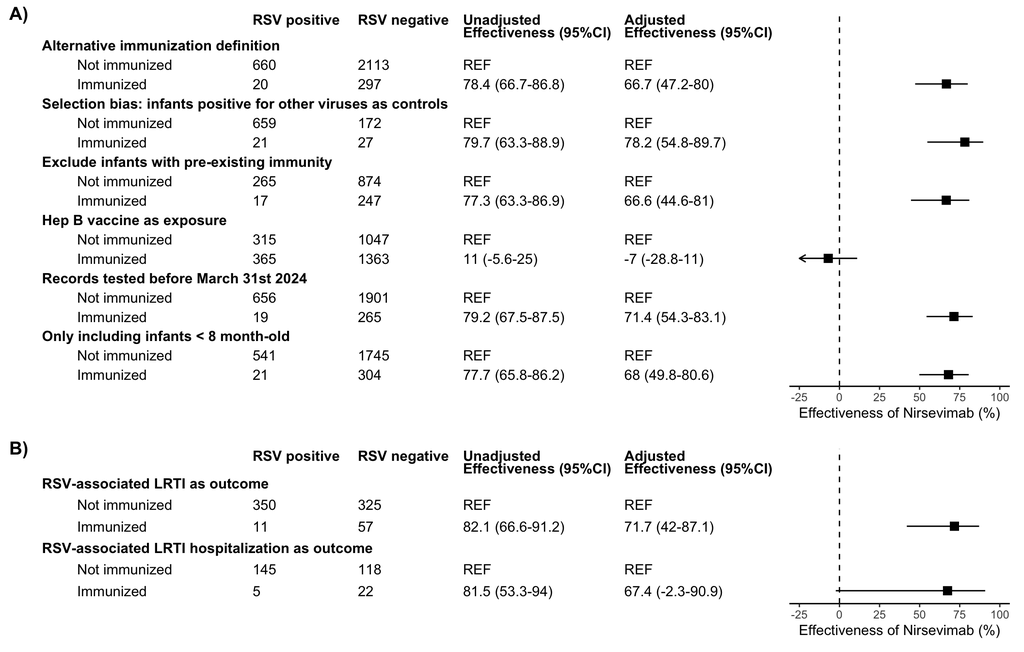